# ATER Digital, Inovação e Difusão Tecnológica · Novos Paradigmas para a Extensão Rural

Extensão Rural

Prof. Dr. Luiz Diego Vidal Santos

## Abertura Visão Geral da Aula

Roteiro da aula Tópicos principais

- 1 Conceito de ATER e Estatização (EMBRATER)
- 2 Freire: Extensão ou Comunicação?
- 3 Andragogia e Métodos Comunicacionais
- 4 ATER Digital e Inclusão Digital
- 5 Difusão Tecnológica como Empoderamento

Objetivo da aula Novos paradigmas da ATER

Explorar os novos paradigmas da extensão rural, da ATER Digital à difusão tecnológica como instrumento de empoderamento e desenvolvimento sustentável.

Lei 6.126/74 PNATER ATER Digital

Como articular tecnologia digital, inclusão rural e comunicação dialógica sem reproduzir o difusionismo unilateral.

# Fundamentos e Crítica ao Difusionismo

## Conceito O que é ATER e a Estatização do Sistema

Assistência Técnica e Extensão Rural Definição operacional

Processos cooperativos, baseados em princípios educacionais, que têm por finalidade levar aos adultos e jovens do meio rural informações sobre inovações na agricultura, pecuária e economia doméstica.

Propõe melhorias a partir de **troca de saberes**.

Marco institucional Lei 6.126/74 · EMBRATER

Estatizou o sistema brasileiro de extensão rural, instituindo a **EMBRATER** e consolidando a rede pública nacional de extensão (Peixoto, 2008).

A transição histórica da ATER envolve superar o repasse vertical de receitas técnicas para consolidar processos cooperativos de educação no campo.

## Histórico O Paradigma Inicial e a Crítica de Freire

Origem negocial Transferência tecnológica vertical

O paradigma inicial da ATER como ferramenta de comunicação **não surgiu** para beneficiar o pequeno produtor. Transvestida de **transferência tecnológica**, a extensão servia como mera ferramenta negocial:

- Atuação da **AIA** (Associação Americana para Desenvolvimento) e seus interesses empresariais
- Abordagem “do **topo para baixo**” (Peixoto, 2008)

Ruptura conceitual Paulo Freire (1980)

> O agrônomo deve transcender a ideia de “extensionista” como mero **artefato de informações técnicas**.

## Freire Freire: Extensão ou Comunicação?

Campo associativo do termo “extensão” Coisificação do sujeito

Freire analisa os sentidos implícitos da palavra **“extensão”**:

- **Invasão cultural**
- Messianismo
- Transmissão

Estes termos **coisificam** o homem do campo, transformando-o em mero receptor.

Proposta de Paulo Freire Agrônomo como comunicador

O agrônomo deve se posicionar como um **“comunicador”**, engajando-se em diálogo **bidirecional e participativo** com as comunidades rurais.

A comunicação autêntica substitui a entrega unilateral de pacotes pela co-construção crítica do conhecimento agronômico.

# Andragogia, Métodos e PNATER

## Educação Andragogia e Métodos Comunicacionais

01 · Paulo Freire Extensão como comunicação

Diálogo horizontal e problematização conjunta da realidade agrária.

02 · Jean Piaget Educação crítica construtivista

Construção ativa do conhecimento a partir da interação com o meio.

03 · José Libâneo Crítica emancipatória

Mediação pedagógica orientada à autonomia e transformação social.

04 · Malcolm S. Knowles Andragogia

Educação de adultos centrada na experiência prévia e autodireção.

A andragogia valoriza a **experiência prévia** do adulto e incentiva o **aprendizado autodirigido** (Knowles, 1980).

## Andragogia Princípios da Andragogia na ATER

| Princípio | Aplicação na ATER |
| --- | --- |
| **Necessidade** | Explorar interesses pessoais do produtor |
| **Autonomia** | Promover capacidade de autogestão |
| **Experiência** | A experiência do agricultor é fundamental |
| **Motivação** | Técnicos como agentes catalisadores |
| **Orientação na realidade** | Ações que caibam na realidade do produtor |
| **Aplicabilidade** | Proposta real — usar e propagar o conhecimento |

Quando respeita os seis princípios andragógicos, a ATER converte o saber prático do agricultor em ponto de partida da inovação.

## Política PNATER (Lei 12.188/2010) e PRONATER

**PNATER — Lei 12.188/2010:** política voltada para a melhoria das condições de vida da população rural, orientada por seis princípios norteadores.

01 · Equidade Inclusão social

Igualdade de direitos e superação de desigualdades no campo.

02 · Agroecologia Transição ecológica

Fomento a práticas agroecológicas e sistemas sustentáveis.

03 · Integração ATER–Pesquisa–Ensino

Articulação contínua entre assistência técnica, pesquisa e ensino.

04 · Diversidade Reconhecimento cultural

Respeito às diversidades da agricultura familiar (Lei 11.326/06).

05 · Economia Geração de renda

Diversificação produtiva e agregação de valor nos territórios.

06 · Governança Atuação em redes

Gestão participativa e cooperação interinstitucional.

# ATER Digital e Difusão de Inovações

## Digital Programa ATER Digital: Ferramentas e Vantagens

O **Programa ATER Digital** insere-se na intersecção entre a **ATER** e a **revolução digital**.

Instrumentos tecnológicos Ferramentas

- Sistemas de Informação Geográfica (SIG)
- Plataformas de aprendizagem online
- Hubs tecnológicos

Ganhos operacionais Vantagens

- Algoritmos de aprendizagem de máquina para identificar **lacunas** no conhecimento
- Abordagem mais **focada e eficiente** na transferência de tecnologia
- Adaptação às **peculiaridades** dos agricultores familiares

## Inclusão Inclusão Digital do Campo (PNAD TIC/IBGE)

| Ano | Domicílios Urbanos (%) | Domicílios Rurais (%) | Diferença |
| --- | --- | --- | --- |
| **2017** | 80% | 41% | 39 p.p. |
| **2018** | 84% | 49% | 35 p.p. |
| **2019** | 87% | 56% | 31 p.p. |
| **2021** | 90% | 72% | 18 p.p. |
| **2022** | 92% | 78% | 14 p.p. |

**Fonte:** PNAD Contínua TIC — IBGE. Avanço acelerado no acesso rural à internet, ainda com hiato de conectividade e letramento digital.

Catalisador territorial Infraestrutura e educação

Fornece **infraestrutura básica** e educação digital para comunidades rurais frequentemente **marginalizadas** em relação ao acesso à tecnologia.

Meio de transformação Resultados esperados

- Eficácia em práticas agrícolas
- Redução do hiato de informação técnica
- Autonomia produtiva com suporte contínuo

## Indicadores Gráfico PNAD Contínua TIC: Urbano vs. Rural

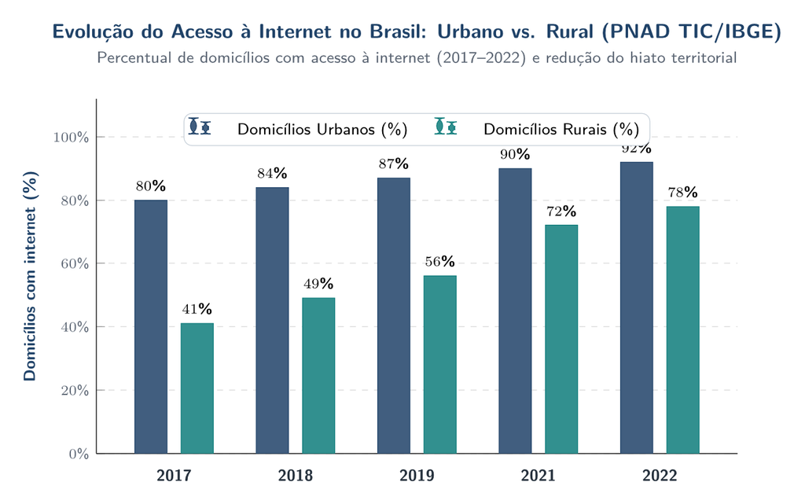

Evolução do Acesso à Internet nos Domicílios Urbanos e Rurais (2017–2022) Elaboração a partir de dados da PNAD Contínua TIC (IBGE): avanço rural de 41% para 78% no período

Apesar da redução do hiato entre 2017 (39 p.p.) e 2022 (14 p.p.), persistem assimetrias regionais, de largura de banda e de letramento digital que exigem **ATER híbrida**.

## Difusão Curva de Difusão (Rogers) e ATER Digital Híbrida

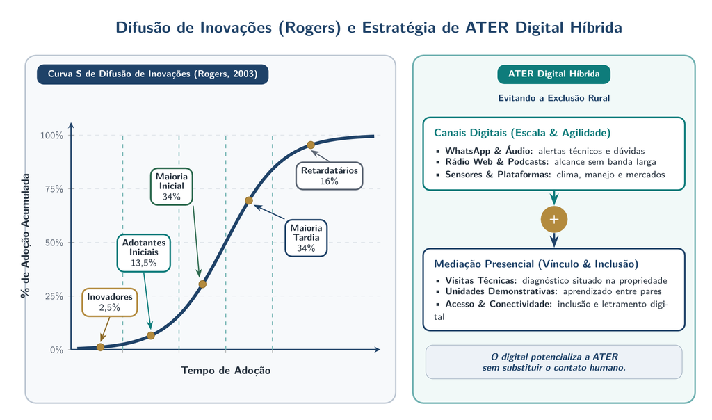

Curva S de Difusão de Inovações de Rogers e estratégia híbrida de ATER Digital.

Difusão de Inovações (Rogers, 2003) e Estratégia de ATER Digital Híbrida Integração entre canais digitais (WhatsApp, podcasts, sensores) e mediação presencial para evitar a exclusão rural

# Participação, Empoderamento e Síntese

## Troca de Saberes Difusão Tecnológica e Diagnóstico Participativo

Processo complexo e contextual Difusão tecnológica (Amorim et al., 2016)

A difusão tecnológica na agropecuária familiar exige:

- Interação sinérgica entre **entidades acadêmicas**, **órgãos governamentais** e **agricultores**
- Processo **dinâmico e bidirecional**, sustentado pela **“troca de saberes”**

Não deve se restringir a tecnologias simplesmente “transmitidas” do campo acadêmico ao produtor.

Diagnóstico Rural Participativo (DRP) Exemplo · Projeto Silvânia (Embrapa Cerrados)

Utiliza análises e diagnósticos situacionais para compreender o contexto:

1. **Análise e diagnóstico** situacional
2. **Experimentação** em unidades rurais selecionadas
3. **Extensão e transferência** adaptada às particularidades edáficas, socioeconômicas e culturais

## Empoderamento Difusão como Empoderamento e Desenvolvimento

01 · Autonomia Empoderamento

Ferramenta de **empoderamento** decisório das famílias agricultoras.

02 · Sustentabilidade Desenvolvimento rural

Instrumento de **desenvolvimento rural sustentável** nos territórios.

03 · Transformação Real desenvolvimento

Supera a métrica exclusiva de **aumento de produtividade**.

**Conceito de desenvolvimento:** postulado por autores como **Amartya Sen**, **Zander Navarro** e **Ricardo Abramovay** — desenvolvimento como **liberdade e autonomia**.

## Síntese Conclusão: Alcance da ATER de Qualidade

As políticas e programas de ATER representam esforços significativos em busca de uma assistência técnica de **qualidade** no campo brasileiro.

**Desenvolvimento rural sustentável:** conciliação entre inovação tecnológica, conservação ambiental e equidade social.

**Fortalecimento da agricultura familiar:** valorização da troca de saberes e da autonomia produtiva.

**Segurança alimentar e nutricional:** ampliação da capacidade produtiva e da diversidade alimentar.

**Redução da pobreza rural:** inclusão digital, produtiva e geração de renda.

**Mitigação das mudanças climáticas:** sistemas resilientes apoiados por tecnologias sociais e digitais.

## Referências Referências Bibliográficas e Marcos Legais

Marcos legais e bases de dados Legislação e levantamentos

- Brasil. Lei 6.126/74 — EMBRATER (1974)
- Brasil. Lei 11.326/06 — Agricultura Familiar (2006)
- Brasil. Lei 12.188/2010 — PNATER/PRONATER (2010)
- IBGE. Pesquisa Nacional por Amostra de Domicílios Contínua — PNAD TIC (2017–2022)

Literatura científica Autores citados

- Amorim et al. Troca de saberes e difusão tecnológica na agricultura familiar (2016)
- Freire, P. *Extensão ou Comunicação* (1979; 1980)
- Knowles, M. S. *A prática moderna da educação de adultos* (1970; 1980)
- Peixoto, M. et al. *Extensão rural no Brasil* (2008)
- Rogers, E. M. *Diffusion of Innovations* (2003)
- Sen, A.; Navarro, Z.; Abramovay, R. Desenvolvimento como liberdade e autonomia